# Analyzing GoBike System Data

### by Hao-Wei Chen

- Introduction
- Preliminary Wrangling
- Univariate Exploration
- Bivariate Exploration
- Multivariate Exploration
- Summary
- Sources

## Introduction

> The data I used for this project is from GoBike System Data. GoBile System (Bay Wheels) is a regional public bicycle sharing system in the San Francisco Bay Area, California operated by Motivate in a partnership with the Metropolitan Transportation Commission and the Bay Area Air Quality Management District. Bay Wheels is the first regional and large-scale bicycle sharing system deployed in California and on the West Coast of the United States. It was established as Bay Area Bike Share in August 2013. As of January 2018, the Bay Wheels system had over 2,600 bicycles in 262 stations across San Francisco, East Bay and San Jose. On June 28, 2017, the system officially re-launched as Ford GoBike in a partnership with Ford Motor Company. After Motivate's acquisition by Lyft, the system was subsequently renamed to Bay Wheels in June 2019. The system is expected to expand to 7,000 bicycles around 540 stations in San Francisco, Oakland, Berkeley, Emeryville, and San Jose.

## Preliminary Wrangling

### What is the structure of your dataset?

After filtering the missing values, there are 79,900 attributes with 13 features (ride_id, rideable_type, started_at, ended_at, start_station_name, start_station_id, end_station_name, end_station_id, start_lat, start_lng, end_lat, end_lng, member_casual) in the orginal dataset. Besides the original columns, I would also like to know the duration time so I created new columns which are started_yr_mo, end_yr_mo, started_at_hour, ended_at_hour, started_at_min, ended_at_min, started_at_sec, ended_at_sec, started_total_sec, ended_total_sec, duratiokn_sec, duration_min and duration_hr. After that, I created a new columns "distance_km" base on the original coulmns 'start_lat', 'start_lng', 'end_lat', 'end_lng'. Finanlly, I only keep 20 columns I might need for my analyses as below,

- ride_id
- rideable_type
- started_at
- ended_at
- start_station_name
- start_station_id
- end_station_name
- end_station_id
- start_lat
- start_lng
- end_lat
- end_lng
- member_casual
- started_at_mon
- ended_at_mon
- started_at_weekday
- duration_sec
- duration_min
- duration_hr
- distance_km

### What is/are the main feature(s) of interest in your dataset?

The main features I am interested in include start_station_name, end_station_name, duration and distance. This can be used to calculate when bikes are in high or low demand. I would also like to know wheather member or casuaul are more willing to use our system. These features can be used to make business decisions such as which rideable type having more casual people and try to enhance our conversion rate (transfer more people from casual to member), whcih day having higher bike demands and so on.

### What features in the dataset do you think will help support your investigation into your feature(s) of interest?

I expect member_casual, rideable_type, start_station_name and end_station_name will be an important features to suppot my investigation. Generally speaking, members are expected to use the system more frequently than the casual users. Although we dont have much information for each station, we still can see which station has less users and try to improve it.

## Univariate Exploration

> In this section, I investigate distributions of individual variables. This is also in preparation to look at the relationships between variables.

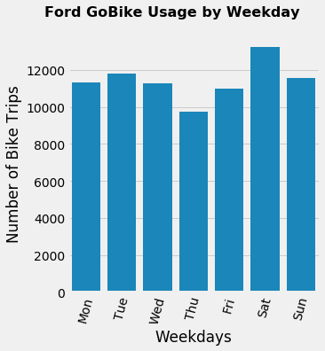

```python
# Weekday usage of the Gobike system

weekday = ['Mon', 'Tue', 'Wed', 'Thu', 'Fri', 'Sat', 'Sun']
graph = sb.catplot(data=df_clean, x='started_at_weekday', kind='count', color = no_color, order = weekday)
graph.set_axis_labels('Weekdays', 'Number of Bike Trips')
graph.fig.suptitle('Ford GoBike Usage by Weekday', y=1.05, fontsize=16, fontweight='bold');
graph.set_xticklabels(rotation=75);
```

#### From above analysis, we can tell that there are more users in Saturday than the other weekdays. Thursday has the less users.

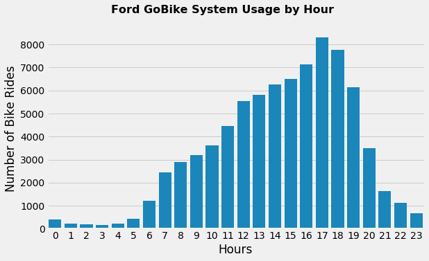

```python
# Hourly usage of the Ford Go Bike System
graph = sb.catplot(data = df_clean, x='started_at_hour', kind='count', color = no_color, aspect = 1.7)
graph.set_axis_labels('Hours', 'Number of Bike Rides')
graph.fig.suptitle('Ford GoBike System Usage by Hour', y=1.05, fontsize=16, fontweight='bold');
```

#### From above analysis, we can tell that most people use the gobike system at 5 pm.

```python
# Observe duration_sec
df_clean['duration_sec'].describe()
```

```
count    79900.000000
mean      1039.245820
std       4475.912832
min     -86258.000000
25%        461.000000
50%        821.000000
75%       1449.000000
max      78242.000000
Name: duration_sec, dtype: float64
```

#### From above analyses, I can tell that the standard deviation is large which means duration time depending on individual user.

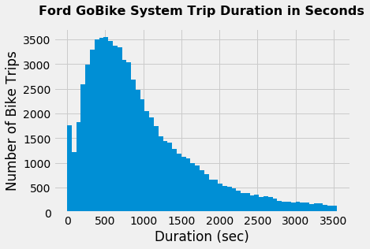

```python
# Duration (seconds) of the bike rides
bin_edges = np.arange(0, 3600, 60)
plt.hist(data = df_clean, x = 'duration_sec', bins = bin_edges);
#plt.grid(b=None)
plt.title("Ford GoBike System Trip Duration in Seconds", y=1.05, fontsize=16, fontweight='bold')
plt.xlabel('Duration (sec)')
plt.ylabel('Number of Bike Trips');
```

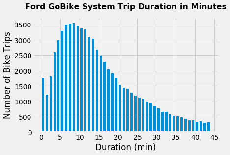

```python
# Duration (minute) of the bike rides
bin_edges = np.arange(0, 45, 1)
ticks = [0, 5, 10, 15, 20, 25, 30,  35, 40, 45]
labels = ['{}'.format(val) for val in ticks]
plt.hist(data = df_clean, x = 'duration_min', bins = bin_edges, rwidth = 0.6);
plt.title("Ford GoBike System Trip Duration in Minutes", y=1.05, fontsize=16, fontweight='bold')
plt.xlabel('Duration (min)')
plt.xticks(ticks, labels)
plt.ylabel('Number of Bike Trips');
```

#### From above two analyses, we can tell that more users are taking around 500 seconds or arond 8 minuates to rike the bike. It suggests that most of the users use the system for short distance.

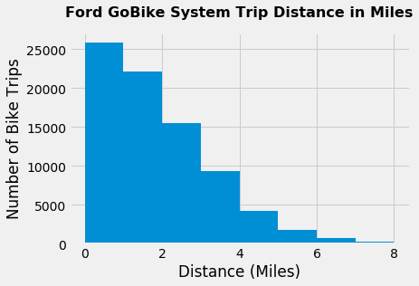

```python
# Distance in km traveled
bin_edges = np.arange(0, 9, 1)

plt.hist(data = df_clean, x = 'distance_km', bins = bin_edges);

plt.title("Ford GoBike System Trip Distance in Miles", y=1.05, fontsize=16, fontweight='bold')
plt.xlabel('Distance (Miles)')
plt.ylabel('Number of Bike Trips');
```

```python
df_clean.distance_km.mean()
```

```
1.867835263196229
```

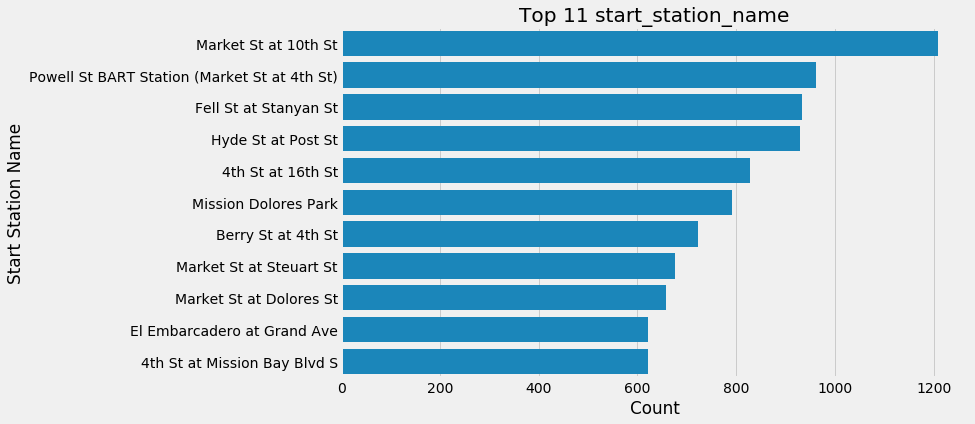

```python
# Top 11 start_station_name

Threshold = 600
make_frequency = df_clean['start_station_name'].value_counts()
idx = np.sum(make_frequency > Threshold)

most_makes = make_frequency.index[:idx]
df_sub = df_clean.loc[df_clean['start_station_name'].isin(most_makes)]

plt.figure(figsize=[10,6])
plt.title('Top 11 start_station_name')
base_color = sb.color_palette()[0]
sb.countplot(data=df_sub, y='start_station_name', color = base_color, order = most_makes);
plt.ylabel('Start Station Name')
plt.xlabel('Count');
```

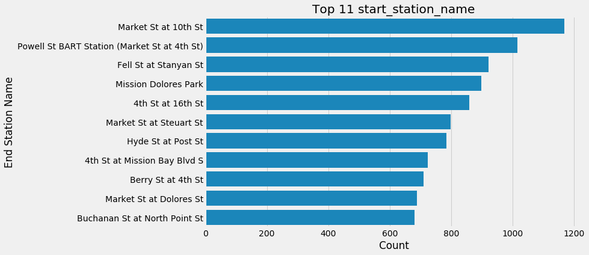

```python
# Top 11 end_station_name

Threshold = 650
make_frequency = df_clean['end_station_name'].value_counts()
idx = np.sum(make_frequency > Threshold)

most_makes = make_frequency.index[:idx]
df_sub = df_clean.loc[df_clean['end_station_name'].isin(most_makes)]

plt.figure(figsize=[10,6])
plt.title('Top 11 start_station_name')
base_color = sb.color_palette()[0]
sb.countplot(data=df_sub, y='end_station_name', color = base_color, order = most_makes);
plt.ylabel('End Station Name')
plt.xlabel('Count');
```

## Bivariate Wrangling

> In this section, I investigate the relationships between pairs of variables in the data.

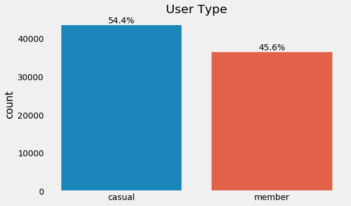

```python
# Observe member_casual

count = len(df_clean)
plt.figure(figsize=[8,5])

ax = sb.countplot(data = df_clean, x = 'member_casual')
ax.grid(False)
plt.title('User Type')
plt.xlabel('');

for i in ax.patches:
    x = i.get_bbox().get_points()[:,0]
    y = i.get_bbox().get_points()[1,1]
    ax.annotate('{:.1f}%'.format(100.*y/count), (x.mean(), y), ha='center', va='bottom')
```

#### From above analysis, I can tell that users who are casual (54.4%) are 8.8% higher than users who are members (45.6%).

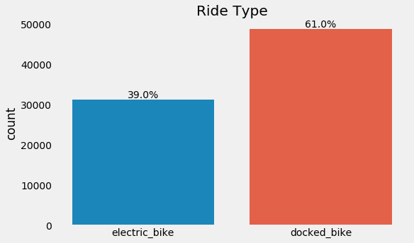

```python
# Observe rideable type

count = len(df_clean)
plt.figure(figsize=[8,5])

ax = sb.countplot(data = df_clean, x = 'rideable_type')
ax.grid(False)
plt.title('Ride Type')
plt.xlabel('');

for i in ax.patches:
    x = i.get_bbox().get_points()[:,0]
    y = i.get_bbox().get_points()[1,1]
    ax.annotate('{:.1f}%'.format(100.*y/count), (x.mean(), y), ha='center', va='bottom')
```

#### From above analysis, I can tell that users who choose docked bike (61.0%) is 22% higher than users who choose electric bike (39%).

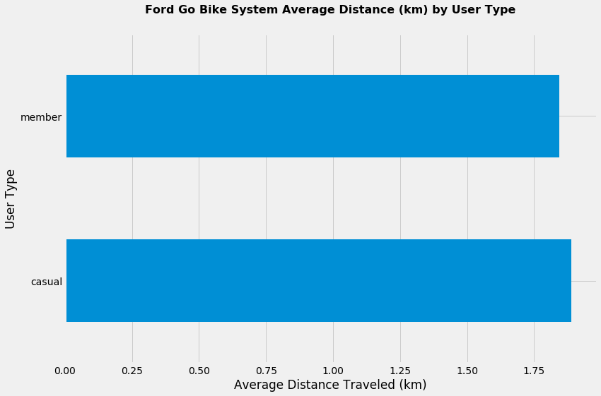

```python
# Customer Usage by Distance vs. Subscriber Usage by Distance
plt = df_clean.groupby('member_casual')['distance_km'].mean().plot(kind='barh', figsize=(12,8));

plt.set_title('Ford Go Bike System Average Distance (km) by User Type', y=1.05, fontsize=16, fontweight='bold')
plt.set_ylabel('User Type')
plt.set_xlabel('Average Distance Traveled (km)');
```

#### From above analysis, we can tell that casual users have the higer average distance than member users.

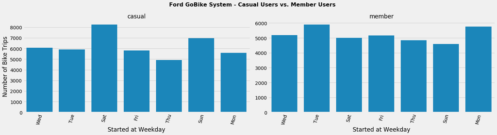

```python
# Casual Users Usage by Duration vs. Member Users Usage by Duration

graph = sb.catplot(data=df_clean, x = 'started_at_weekday', col='member_casual', kind='count', sharey = False, color = no_color, height=5, aspect=2);

graph.set_axis_labels('Started at Weekday', 'Number of Bike Trips')
graph.set_titles('{col_name}')

graph.fig.suptitle('Ford GoBike System - Casual Users vs. Member Users', y=1.05, fontsize=16, fontweight='bold');
graph.set_xticklabels(rotation=75);
```

## Multivariate Exploration

> I investigate plots of three or more variables to dig into the data further.

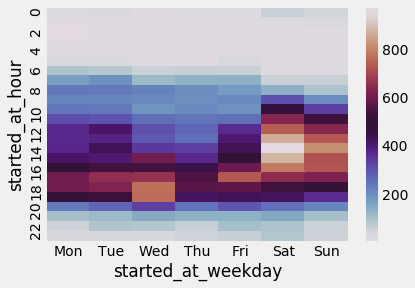

```python
# Weekday order
weekday = ['Mon', 'Tue', 'Wed', 'Thu', 'Fri', 'Sat', 'Sun']
df_clean['started_at_weekday'] = pd.Categorical(df_clean['started_at_weekday'], categories= ['Mon', 'Tue', 'Wed', 'Thu', 'Fri', 'Sat', 'Sun'], ordered=True);

df_casual = df_clean.query('member_casual == "casual"').groupby(['started_at_hour', 'started_at_weekday'])['ride_id'].size().reset_index();
df_casual = df_casual.pivot('started_at_hour', 'started_at_weekday', 'ride_id')

heat_map = sb.heatmap(df_casual, cmap = 'twilight')

plt.set_title('Casual User', y=1.05)
plt.set_xlabel('Weekday', labelpad = 16)
plt.set_ylabel('Start Time Hour',  labelpad = 16)
```

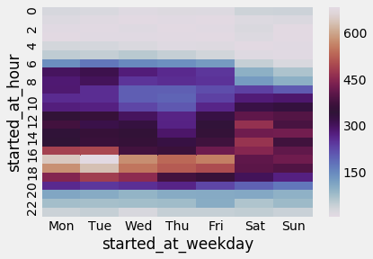

```python
df_member = df_clean.query('member_casual == "member"').groupby(['started_at_hour', 'started_at_weekday'])['ride_id'].size().reset_index();
df_member = df_member.pivot('started_at_hour', 'started_at_weekday', 'ride_id')
hot_map = sb.heatmap(df_member, cmap = 'twilight')

plt.set_title("Subscriber", y=1.05)
plt.set_xlabel('Weekday', labelpad = 16)
plt.set_ylabel('Start Time Hour', labelpad = 16);
```

#### Casual users use the system more often on weekends, while member users primarily use the bikes on weekdays.

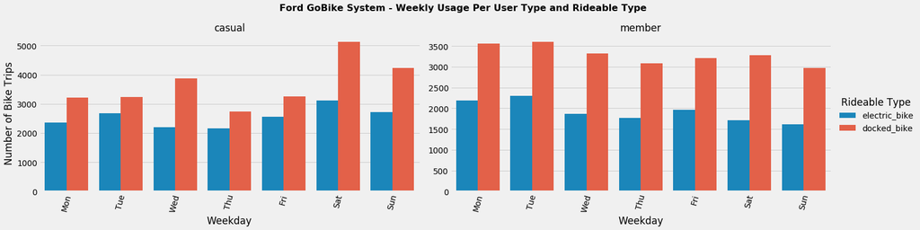

```python
# Weekly usage - user type and rideable type
graph = sb.catplot(data=df_clean, x='started_at_weekday', col="member_casual", hue="rideable_type", kind='count', sharey = False, height=5, aspect=2);

graph.set_axis_labels("Weekday", "Number of Bike Trips")
graph._legend.set_title('Rideable Type')
graph.set_titles("{col_name}")

graph.fig.suptitle('Ford GoBike System - Weekly Usage Per User Type and Rideable Type', y=1.05, fontsize=16, fontweight='bold');
graph.set_xticklabels(rotation=75);
```

### Were there any interesting or surprising interactions between features?

> Nothing out of the expected here. It was interesting to compare weekly difference for casual users v.s member users, and see the trend for the electric bike and docked bike.